# Part I - (Exploration on the FordGoBike Dataset )

## by (Christopher Ohwavworua)

## Introduction

> This data set includes information about individual rides made in a bike-sharing system covering the greater San Francisco Bay area. It covers the detais of 183412 rides observed in 16 different columns. These details include the duration of rides in seconds, the statr and end time of rides,the stsrt and end station names, the geographical positions of the start and end stations, the year of birth of riders, the sex of the riders, and the user type of the riders.

## Preliminary Wrangling

```python
# import all packages and set plots to be embedded inline
import numpy as np
import pandas as pd
import matplotlib.pyplot as plt
import seaborn as sb
%matplotlib inline
from pandas import CategoricalDtype
pd.set_option('max_columns',16)
```

```python
#Loading the data Fordgobike dataset
df = pd.read_csv('201902-fordgobike-tripdata.csv')
```

### Accessing data

```python
df.shape
```

```
(183412, 16)
```

```python
df.head(5)
```

|  | duration_sec | start_time | end_time | start_station_id | start_station_name | start_station_latitude | start_station_longitude | end_station_id | end_station_name | end_station_latitude | end_station_longitude | bike_id | user_type | member_birth_year | member_gender | bike_share_for_all_trip |
| --- | --- | --- | --- | --- | --- | --- | --- | --- | --- | --- | --- | --- | --- | --- | --- | --- |
| 0 | 52185 | 2019-02-28 17:32:10.1450 | 2019-03-01 08:01:55.9750 | 21.0 | Montgomery St BART Station (Market St at 2nd St) | 37.789625 | -122.400811 | 13.0 | Commercial St at Montgomery St | 37.794231 | -122.402923 | 4902 | Customer | 1984.0 | Male | No |
| 1 | 42521 | 2019-02-28 18:53:21.7890 | 2019-03-01 06:42:03.0560 | 23.0 | The Embarcadero at Steuart St | 37.791464 | -122.391034 | 81.0 | Berry St at 4th St | 37.775880 | -122.393170 | 2535 | Customer | NaN | NaN | No |
| 2 | 61854 | 2019-02-28 12:13:13.2180 | 2019-03-01 05:24:08.1460 | 86.0 | Market St at Dolores St | 37.769305 | -122.426826 | 3.0 | Powell St BART Station (Market St at 4th St) | 37.786375 | -122.404904 | 5905 | Customer | 1972.0 | Male | No |
| 3 | 36490 | 2019-02-28 17:54:26.0100 | 2019-03-01 04:02:36.8420 | 375.0 | Grove St at Masonic Ave | 37.774836 | -122.446546 | 70.0 | Central Ave at Fell St | 37.773311 | -122.444293 | 6638 | Subscriber | 1989.0 | Other | No |
| 4 | 1585 | 2019-02-28 23:54:18.5490 | 2019-03-01 00:20:44.0740 | 7.0 | Frank H Ogawa Plaza | 37.804562 | -122.271738 | 222.0 | 10th Ave at E 15th St | 37.792714 | -122.248780 | 4898 | Subscriber | 1974.0 | Male | Yes |

```python
df.info()
```

```
<class 'pandas.core.frame.DataFrame'>
RangeIndex: 183412 entries, 0 to 183411
Data columns (total 16 columns):
 #   Column                   Non-Null Count   Dtype
---  ------                   --------------   -----
 0   duration_sec             183412 non-null  int64
 1   start_time               183412 non-null  object
 2   end_time                 183412 non-null  object
 3   start_station_id         183215 non-null  float64
 4   start_station_name       183215 non-null  object
 5   start_station_latitude   183412 non-null  float64
 6   start_station_longitude  183412 non-null  float64
 7   end_station_id           183215 non-null  float64
 8   end_station_name         183215 non-null  object
 9   end_station_latitude     183412 non-null  float64
 10  end_station_longitude    183412 non-null  float64
 11  bike_id                  183412 non-null  int64
 12  user_type                183412 non-null  object
 13  member_birth_year        175147 non-null  float64
 14  member_gender            175147 non-null  object
 15  bike_share_for_all_trip  183412 non-null  object
dtypes: float64(7), int64(2), object(7)
memory usage: 22.4+ MB
```

#### Data quality

1. Missing data in the following columns(start_station_name,end_station_name,member_gender,member_birth_year)
2. Data type format for start_time and end_time set as Object
3. Start and end station id to be deleted
4. vauge column name duration_sec
5. outliers observed in member age distribution.
6. outliers observed in the bike ride duration distribution.

### Data Cleaning

#### Define

1. Droping all missing data in the following columns(start_station_name,end_station_name,member_gender,member_birth_year)
2. Coverting data type for start_time and end_time to datetime type and bike id to objects
3. Droping all columns not relevant for our analysis.
4. Changing the name of column for clarity
5. droping records where member age is greater than 80
6. droping records where bike duration exceeds 120 mins
7. Creating cloumns such as start day of week, start date of the week and start hour of the day.
8. converting the measure of duration of bike ride to minutes

#### Code

```python
# Changing the data type for start_time, end_time and bike id

df['end_time'] = pd.to_datetime(df['end_time'], format = '%Y-%m-%d %H:%M:%S')
df['start_time'] = pd.to_datetime(df['start_time'], format = '%Y-%m-%d %H:%M:%S')
df['bike_id'] = df['bike_id'].astype(str)
```

```python
# Droping all columns not relevant for the purpose of this analysis

df.drop(['end_station_latitude','end_station_longitude','start_station_id','end_station_id','start_station_latitude','start_station_longitude'], axis = 1, inplace = True)
```

```python
# droping all Nan values in the following columns(start_station_name,end_station_name,member_gender,member_birth_year)

df.dropna(inplace = True)
```

```python
# Creating a new column for member age and droping the column for member birth year.
df['member_age'] = df['member_birth_year'].apply(lambda x: 2022-x).astype("int64")
```

```python
# droping records where member age is greater than 80
filt = df['member_age'] > 80
df.drop(index = df.loc[filt].index,inplace = True)
```

```python
#Converting time duration measured in sec to minutes
df['ride_duration_in_mins'] = df['duration_sec'].apply(lambda x: x/60).round(2)
```

```python
# droping records where bike ride duration greater than 120
timefilt = df['ride_duration_in_mins']>120
df.drop(index = df.loc[timefilt].index,inplace = True)
```

```python
# creating new columns for Day_of_week and date
df['Start_date'] = df['start_time'].dt.strftime('%d')
df['Hour_of_day'] = df['start_time'].dt.strftime('%H')
df['day_of_week']= df['start_time'].dt.day_name()
```

```python
df.sample(2)
```

|  | duration_sec | start_time | end_time | start_station_name | end_station_name | bike_id | user_type | member_birth_year | member_gender | bike_share_for_all_trip | member_age | ride_duration_in_mins | Start_date | Hour_of_day | day_of_week |
| --- | --- | --- | --- | --- | --- | --- | --- | --- | --- | --- | --- | --- | --- | --- | --- |
| 169459 | 936 | 2019-02-04 10:01:30.169 | 2019-02-04 10:17:07.136 | Potrero Ave and Mariposa St | The Embarcadero at Bryant St | 230 | Subscriber | 1990.0 | Male | No | 32 | 15.6 | 04 | 10 | Monday |
| 92297 | 978 | 2019-02-15 19:13:43.860 | 2019-02-15 19:30:02.489 | Union Square (Powell St at Post St) | Valencia St at 22nd St | 6139 | Subscriber | 1995.0 | Male | No | 27 | 16.3 | 15 | 19 | Friday |

```python
df.info()
```

```
<class 'pandas.core.frame.DataFrame'>
Int64Index: 174202 entries, 4 to 183411
Data columns (total 15 columns):
 #   Column                   Non-Null Count   Dtype
---  ------                   --------------   -----
 0   duration_sec             174202 non-null  int64
 1   start_time               174202 non-null  datetime64[ns]
 2   end_time                 174202 non-null  datetime64[ns]
 3   start_station_name       174202 non-null  object
 4   end_station_name         174202 non-null  object
 5   bike_id                  174202 non-null  object
 6   user_type                174202 non-null  object
 7   member_birth_year        174202 non-null  float64
 8   member_gender            174202 non-null  object
 9   bike_share_for_all_trip  174202 non-null  object
 10  member_age               174202 non-null  int64
 11  ride_duration_in_mins    174202 non-null  float64
 12  Start_date               174202 non-null  object
 13  Hour_of_day              174202 non-null  object
 14  day_of_week              174202 non-null  object
dtypes: datetime64[ns](2), float64(2), int64(2), object(9)
memory usage: 21.3+ MB
```

```python
df.describe()
```

|  | duration_sec | member_birth_year | member_age | ride_duration_in_mins |
| --- | --- | --- | --- | --- |
| count | 174202.000000 | 174202.000000 | 174202.000000 | 174202.000000 |
| mean | 639.585740 | 1984.882763 | 37.117237 | 10.659756 |
| std | 538.793962 | 9.866836 | 9.866836 | 8.979893 |
| min | 61.000000 | 1942.000000 | 21.000000 | 1.020000 |
| 25% | 323.000000 | 1980.000000 | 30.000000 | 5.380000 |
| 50% | 509.000000 | 1987.000000 | 35.000000 | 8.480000 |
| 75% | 785.000000 | 1992.000000 | 42.000000 | 13.080000 |
| max | 7174.000000 | 2001.000000 | 80.000000 | 119.570000 |

```python
# saving the dataset
pd = df.to_csv('Fordgobike_clean', index = False)
```

```python
#making a copy of the dataset.
df_clean = df.copy()
```

```python
df_clean.shape
```

```
(174202, 15)
```

### What is the structure of your dataset?

The dataset to be analyzed consist of 174202 entries represented in 15 different columns after cleaning.

### What is/are the main feature(s) of interest in your dataset?

The main features of interest in this dataset includes data in the following columns:

1. ride_duration_in_mins
2. start_time
3. user_type
4. member_gender
5. day_of_week
6. Hour_of_day

### What features in the dataset do you think will help support your investigation into your feature(s) of interest?

Data values for all the columns listed above in the dataset will be of great assistace in answering questions related to this analysis as comparisons will be made between each gender and user type in relation to time, houe of day and day of week.

## Univariate Exploration

#### Visualizing individual variables to observe the distributions

```python
# Creating a function that to set labels and titles

def label(x,y,t):
    """
    Args:
    x(str): 'x-axis title'
    y(str): 'y-axis title'
    t(str): 'main title'
    Returns:
    None

    """
    plt.xlabel(x,fontsize = 10, weight = 'bold')
    plt.ylabel(y,fontsize = 10, weight = 'bold')
    plt.title(t,fontsize = 15, weight = 'bold')
```

```python
# Creating a function for my count plots

def myCountPlot(df_clean,xVar):
    base_color = sb.color_palette()[0]
    asc = df_clean[xVar].value_counts().index
    plt.figure(figsize=(12,6))
    sb.countplot(data=df_clean,x= xVar,color=base_color,order=asc)
    plt.title(f'''Distribution of {xVar}'''.title(), fontsize = 14, weight = 'bold')
    plt.xlabel(xVar.title(), fontsize = 10, weight = 'bold')
    plt.ylabel('Frequency'.title(),fontsize = 10, weight = 'bold')
```

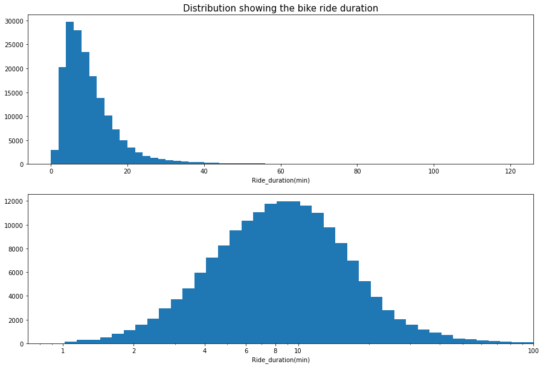

```python
# histogram showing the distribution of the time taken to complete rides(ride_duration_in_mins)

plt.figure(figsize=[15,10])
plt.subplot(2,1,1)
bins = np.arange(0,df_clean['ride_duration_in_mins'].max() + 2, 2)
plt.hist(data=df_clean, x='ride_duration_in_mins', bins=bins);
plt.xlabel('Ride_duration(min)')
plt.title('Distribution showing the bike ride duration',fontsize =15);


plt.subplot(2,1,2)
bins =10 ** np.arange(0.008600,3.148951 + 0.05, 0.05 )
plt.hist(data=df_clean, x='ride_duration_in_mins', bins=bins);
plt.xlabel('Ride_duration(min)')
plt.xscale('log')
plt.xticks([1,2,4,6,8,1e1,1e2, 200], [1,2,4,6,8,10,100,200])
plt.xlim(0,100)
plt.show();
```

```python
df['ride_duration_in_mins'].describe()
```

```
count    174202.000000
mean         10.659756
std           8.979893
min           1.020000
25%           5.380000
50%           8.480000
75%          13.080000
max         119.570000
Name: ride_duration_in_mins, dtype: float64
```

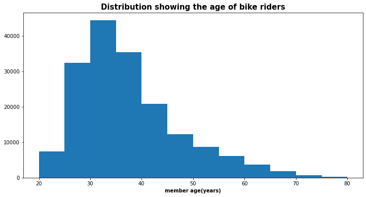

```python
# Dist plot showing the age member distribution of bike riders

plt.figure(figsize=[12, 6])
base_color=sb.color_palette()[0]
bins = np.arange(20,df_clean['member_age'].max() + 5, 5)
plt.hist(data=df_clean, x='member_age', bins=bins,color =base_color )
plt.title('Distribution showing the age of bike riders',fontsize =15,weight='bold')
plt.xlabel('member age(years)',fontsize =10,weight='bold');
```

```python
df_clean['member_age'].describe()
```

```
count    174202.000000
mean         37.117237
std           9.866836
min          21.000000
25%          30.000000
50%          35.000000
75%          42.000000
max          80.000000
Name: member_age, dtype: float64
```

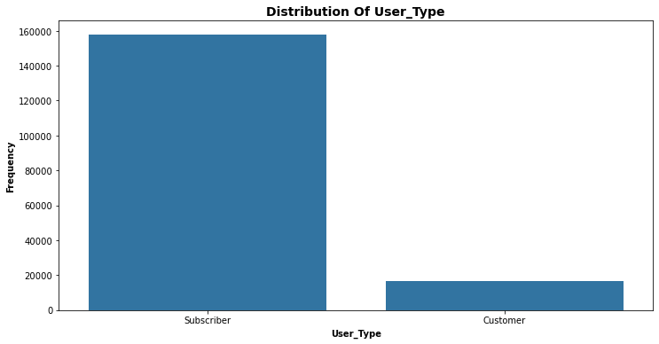

```python
# Bar chart showing the value counts of Users types of the FordGoBike.
myCountPlot(df_clean, 'user_type')
```

The plot above shows that above one hundred and fifty thpousand users were subscribers while customers were a little below twenty thousand.

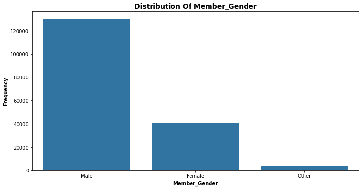

```python
# plot showing the member_gender of the fordgobike users
myCountPlot(df_clean, 'member_gender')
```

The bar chart above reveals three gender set. Over a hundred and twenty thousand users were identified as males, just above fourty thousand were identified as females and below five thouand had revealed their identity as others.

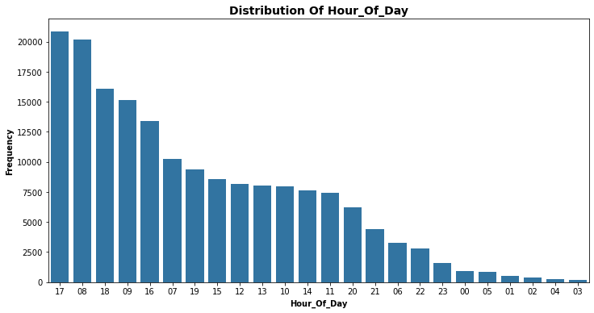

```python
# plot showing hour of the day has the most traffic as regard starting bikerides

myCountPlot(df_clean, 'Hour_of_day')
```

The bar chart above shows the frequency counts of the bike rides started in various hours of the day. The chart reveals that 17hrs(5pm) recorded the most frequency.

### Discuss the distribution(s) of your variable(s) of interest. Were there any unusual points? Did you need to perform any transformations?

> The distribution showing the duration of rides showed a very thin density area because of the very large range of values involved. A logrithimic transform was done on the scale to zoom closer into the distribution.

### Of the features you investigated, were there any unusual distributions? Did you perform any operations on the data to tidy, adjust, or change the form of the data? If so, why did you do this?

> There was an unusual observations on the member age distribution. It was observed that some persons that had the bike ride were over a hundred years old. In reality, this is practically impossible as i suspect that errors were made while capturing the year of birth data. So for all riders that were above 80 years their records were deleted.

## Bivariate Exploration

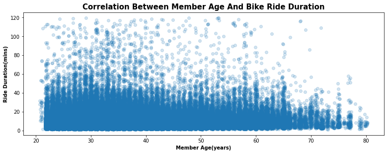

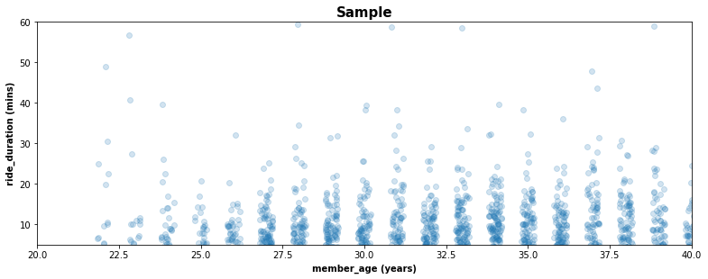

```python
# Using a scatter plot to show the relationship between the member age and bike ride duration.
plt.figure(figsize = [13, 10])
plt.subplot(2,1,1)
sb.regplot(data = df_clean, x = 'member_age', y = 'ride_duration_in_mins', fit_reg = False,
           x_jitter = 0.3, scatter_kws ={'alpha':0.2})
label('Member Age(years)', 'Ride Duration(mins)', 'Correlation Between Member Age And Bike Ride Duration')


# sample scatter plot showing relationship between the member age and bike ride duration.
plt.figure(figsize = [13, 10])
plt.subplot(2,1,2)
df_sample = df_clean.sample(2000)
sb.regplot(data = df_sample, x = 'member_age', y = 'ride_duration_in_mins', fit_reg = False,
           x_jitter = 0.2, scatter_kws ={'alpha':0.2})
label('member_age (years)', 'ride_duration (mins)', 'Sample')
plt.xlim(20,40)
plt.ylim(5,60);
```

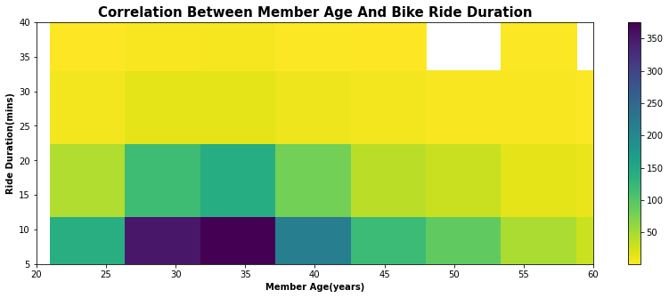

```python
# 2d hist plot showing the relationship between the member age and duration of ride.

plt.figure(figsize = [14, 5])
df_sample = df_clean.sample(2000)
plt.hist2d(data = df_sample, x = 'member_age', y = 'ride_duration_in_mins', cmin = 0.5, cmap = 'viridis_r')
plt.colorbar()
label('Member Age(years)', 'Ride Duration(mins)', 'Correlation Between Member Age And Bike Ride Duration')
plt.xlim(20,60)
plt.ylim(5,40);
```

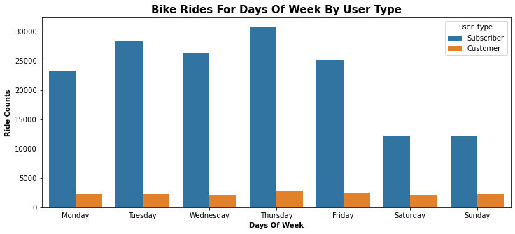

```python
# plot showing the bikerides counts for each weekday by usertype

day_name = ["Monday","Tuesday","Wednesday","Thursday","Friday","Saturday","Sunday"]
asc = df_clean['day_of_week'].value_counts().index
plt.figure(figsize = [12, 5])
sb.countplot(data = df_clean, x='day_of_week', hue = 'user_type', order = day_name)
label('Days Of Week', 'Ride Counts', 'Bike Rides For Days Of Week By User Type');
```

The plot above shows the bike ride frequency for each day of the week categorized by the user type. The plot reveals that for each day of week, there was more patronage from subscribers. Cumulatively, thursday and tuesdays recorded the most bike rides completed while the weekends i.e sunday and saturday recorded the least patronage.

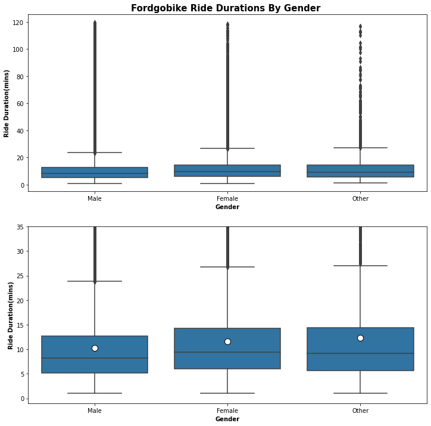

```python
# Boxplot showing the duration in minutes by gender

plt.figure(figsize = [12, 12])
plt.subplot(2,1,1)
gen_order = df_clean['member_gender'].value_counts().index
sb.boxplot(data=df_clean, x='member_gender', y='ride_duration_in_mins',color=base_color, order = gen_order)
label('Gender', 'Ride Duration(mins)', 'Fordgobike Ride Durations By Gender ');



# Boxplot showing the duration in minutes by gender without outliers
plt.subplot(2,1,2)
sb.boxplot(data=df_clean, x='member_gender', y='ride_duration_in_mins',color=base_color, order = gen_order,
          showmeans = True, meanprops = {'markerfacecolor':'white','markersize':10, 'markeredgecolor':'black','marker':'o'})
label('Gender', 'Ride Duration(mins)', '')
plt.ylim([-1,35]);
```

Figure 1, of the above box plot reveals long outlier positions for bike ride duration for all gender type. Figure 2 was plotted to limit the outliers on the ride duration axis of the plot for clarity purpose. The plot reveals that the mean value of bike ride durations for female was greater than that of the males. This invarably suggest that the males complete their rides faster than the females. Also, the persons with other gender type had the most mean value for bike ride duration.

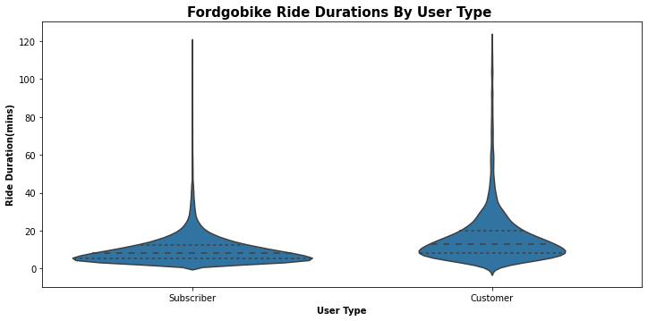

```python
# Violin plot showing the ride durations by user type

plt.figure(figsize = [12, 12])
plt.subplot(2,1,1)
sb.violinplot(data=df_clean, x='user_type', y='ride_duration_in_mins',color=base_color,inner = 'quartile')
label('User Type', 'Ride Duration(mins)', 'Fordgobike Ride Durations By User Type ');
```

### Talk about some of the relationships you observed in this part of the investigation. How did the feature(s) of interest vary with other features in the dataset?

> The relationship between the gender type and the bike ride duration was one that supports the general saying that females are the weaker gender physically. It showed that the mean period for ride completing for females was greater than that of the males. Alternatively, it could be said that the males spend lesser time completing their rides. Also the count of bike rides per day of week revealed that the weekends(saturdays and sundays) do not really command much traffic as regards bike rides. This could also suggest that economic activities during weekends in sanfrancisco is relatively low when compared to week days.

### Did you observe any interesting relationships between the other features (not the main feature(s) of interest)?

> The relationship between the frequency of bike rides for customers and subcribers over the week is one that requires a further investigation. From the chart, an almost even frequency of bike rides was observed for custpomers while there was a very significant observation of frequency variation per week day.

## Multivariate Exploration

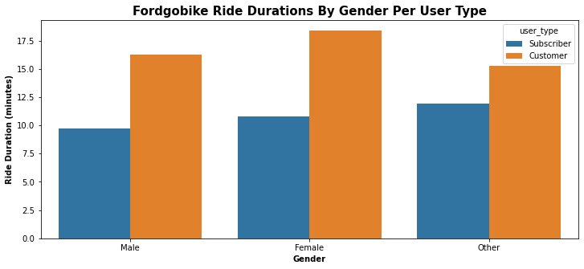

```python
# Bar plots showing the duration in minutes by gender for each user type.
plt.figure(figsize = [12, 5])
sb.barplot(data=df_clean, x='member_gender', y='ride_duration_in_mins', hue='user_type',hue_order = ['Subscriber','Customer'], ci=None)
label('Gender', 'Ride Duration (minutes)', 'Fordgobike Ride Durations By Gender Per User Type');
```

The bar graph above shows the mean duration for each gender categorized by the user type. The chart above confirms that the mean duration to complete a ride for female customers is greater than that of male customers. Also the mean duration to complete a ride for female subscribers is more than that of male subscribers.

```python
# Plot showig the trend of bike rides for each weekday by gender and user type.
```

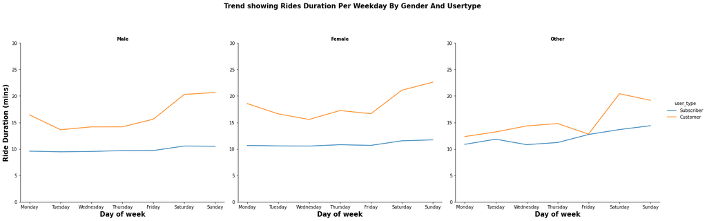

```python
plt.figure(figsize = [40,20])
wkday = ["Monday","Tuesday","Wednesday","Thursday","Friday","Saturday","Sunday"]
df_clean['day_of_week']= df_clean['day_of_week'].astype(CategoricalDtype(wkday, ordered = True))
g =sb.FacetGrid(data = df_clean, col = 'member_gender',height= 7, sharey=False, ylim = (0,30),hue = 'user_type')
g.map_dataframe(sb.lineplot, x='day_of_week', y ='ride_duration_in_mins',ci=None)
g.set_axis_labels('Day of week','Ride Duration (mins)', fontsize = 15,weight = 'bold')
g.add_legend()
g.set_titles(col_template = '{col_name}',fontsize = 30, weight = 'bold')
g.fig.subplots_adjust(top=0.8)
g.fig.suptitle('Trend showing Rides Duration Per Weekday By Gender And Usertype',fontsize = 15, weight = 'bold');
```

The line chart above shows the bike ride duration for each weekday per gender and user type. Although, it was observed that the weekends(saturday and sunday) recorded the least counts of rides. But when compared to the duration for rides completed by each gender per user type, the line chart reveals that the mean time for rides completed for saturdays and sundays was the most. This could trigger the suggestion that most rides taken on weekends might be for liesure or exercise purposes as the riders are not in a hurry to complete the rides. A further investigation concerning this suggestion will be looked upon in future anaalysis.

### Talk about some of the relationships you observed in this part of the investigation. Were there features that strengthened each other in terms of looking at your feature(s) of interest?

> The relationship between the member gender and the period of bike ride confirmed that females take longer time to complete their rides.

### Were there any interesting or surprising interactions between features?

> During this exploration, an interestion observation mas made as regards the duration of bike rides on each weekday. Given that it was previously recorded that ride count for the weekends(saturday and sunday) was the least, the same could not be said when comparing the mean duration of rides completed for each weekday which shows that the weekend(saturday and sunday) had the highest mean period.